# Krzysztof Jankowski HW6

### Dataset

I used the dataset from previous homework - pc1 dataset from openml that analyses the defects in the software. I preprocessed it using StandardScaler and LabelEncoder for the labels to be in [0, 1] set. I also split the dataset into train and test sets with test set consisting of 33% of the data.

### Models

I trained 4 models:

- RandomForest with default hyperparameters (my primary model)
- XGBoost with default hyperparameters (first compare model)
- LogisticRegression with default hyperparameters (second compare model)
- RandomForest with n_estimators=10, max_depth=10 which I later call SmallRandomForest (third compare model)

Below I present the performance of the models:

[output not shown]

Highest results in respective metrics are bolded. XGBoost and RandomForest have good performance and outperform other models in almost all metrics.

### PVI for RandomForest

Below I present the PVI plot for the RandomForest model:

[figure not shown]

The most important feature is the uniqOpnd followed by IOBlank and I. In the dataset these variables are associated with respectively number of unique operands in the code, number of blank lines and the length of the code. It is rational that when writing code these variables are significant when it comes to vulnerability analysis. We may also hypothesise that these variables are correlated as it makes sense that with higher number of lines naturally comes a higher number of blank lines of codes and number of operands, so let's look at the correlation matrix between variables that are present in the PVI plot above:

[figure not shown]

### PVI for other models

Now let's compare the pvi plots for the other models.

[output not shown]

#### RandomForest vs SmallRandomForest

Let's first start with the comparison of RandomForest and SmallRandomForest. The first 4 variables are the same which is not surprising as the models share the same architecture with different hyperparameters. The smaller model however emphasises more the importance of uniq_Opnd suggesting that larger RandomForest can better distinguish the nuances between variables and focus on impact of other ones.

#### RandomForest vs XGBoost

In this case XGBoost focuses on a different most important variable namely I - length of the code. Second most important variable is the same in both models. Interestingly the third most important variable in XGBoost is uniqOp - number of unique operators which was not present in top 10 most important variables for RandomForest.

#### Comments

As we could have seen previously many variables are correlated, so tree-based models better capture the nuances between the variables, however it is interesting that both LogisticRegression and XGBoost focus a lot on uniq_Op whereas RandomForest does not.

### Comparison of PVI for RandomForest with other methods

The plot below presents the comparison of PVI and other methods - Gini and SHAP for RandomForest model.

[output not shown]

[figure not shown]

## Appendix

### Dataset

```python
# uncomment if you don't have dalex or shap installed
# !pip install dalex
# !pip install shap
```

```python
from sklearn.preprocessing import LabelEncoder, StandardScaler
from sklearn.datasets import fetch_openml
from sklearn.model_selection import train_test_split
import pandas as pd

X, y = fetch_openml('pc1', return_X_y=True)
standard_scaler = StandardScaler()
standard_scaler.fit(X)
X = pd.DataFrame(standard_scaler.transform(X), columns=X.columns)

le = LabelEncoder()
y = le.fit_transform(y)

display(X.head())
display(y[:5])
print(X.shape, y.shape)

X_train, X_test, y_train, y_test = train_test_split(X, y, test_size=0.33, random_state=42)
```

[output not shown]

|  | loc | v(g) | ev(g) | iv(G) | N | V | L | D | I | E | ... | T | lOCode | lOComment | locCodeAndComment | lOBlank | uniq_Op | uniq_Opnd | total_Op | total_Opnd | branchCount |
| --- | --- | --- | --- | --- | --- | --- | --- | --- | --- | --- | --- | --- | --- | --- | --- | --- | --- | --- | --- | --- | --- |
| 0 | -0.631622 | -0.459046 | -0.245601 | -0.300256 | -0.588566 | -0.462872 | 7.969369 | -0.863205 | -0.893495 | -0.168975 | ... | -0.168846 | -0.608907 | -0.256439 | 0.315512 | -0.385967 | -1.480420 | -0.678168 | -0.584789 | -0.576122 | -0.494553 |
| 1 | -0.634457 | -0.503714 | -0.317476 | -0.362765 | -0.590087 | -0.463071 | 5.926964 | -0.881576 | -0.901977 | -0.168977 | ... | -0.168878 | -0.638705 | -0.351553 | 0.016450 | -0.467296 | -1.504874 | -0.685056 | -0.586581 | -0.578440 | -0.518747 |
| 2 | 1.917424 | 0.389648 | 0.041900 | -0.206493 | 1.017028 | 0.920890 | -0.608731 | 0.752212 | 1.203377 | 0.170082 | ... | 0.170082 | 1.715323 | 3.738348 | 3.007069 | 1.972589 | 1.918722 | 1.553365 | 1.124079 | 0.870503 | 0.449002 |
| 3 | 2.427800 | 1.729691 | 0.401277 | 2.293854 | 1.336423 | 1.224661 | -0.608731 | 0.794465 | 1.608220 | 0.254797 | ... | 0.254796 | 2.221885 | 3.453006 | 3.306131 | 1.403282 | 1.796451 | 1.863300 | 1.455463 | 1.171883 | 1.719172 |
| 4 | 13.656075 | 11.221663 | 6.870055 | 12.295243 | 11.263018 | 13.253154 | -0.812972 | 3.706872 | 6.775907 | 9.044464 | ... | 9.044465 | 12.949100 | 6.306425 | 14.072361 | 3.436519 | 6.198217 | 12.952091 | 11.916457 | 10.329205 | 10.186974 |

5 rows × 21 columns

```
array([0, 1, 1, 1, 1])
```

```
(1109, 21) (1109,)
```

### Correlation

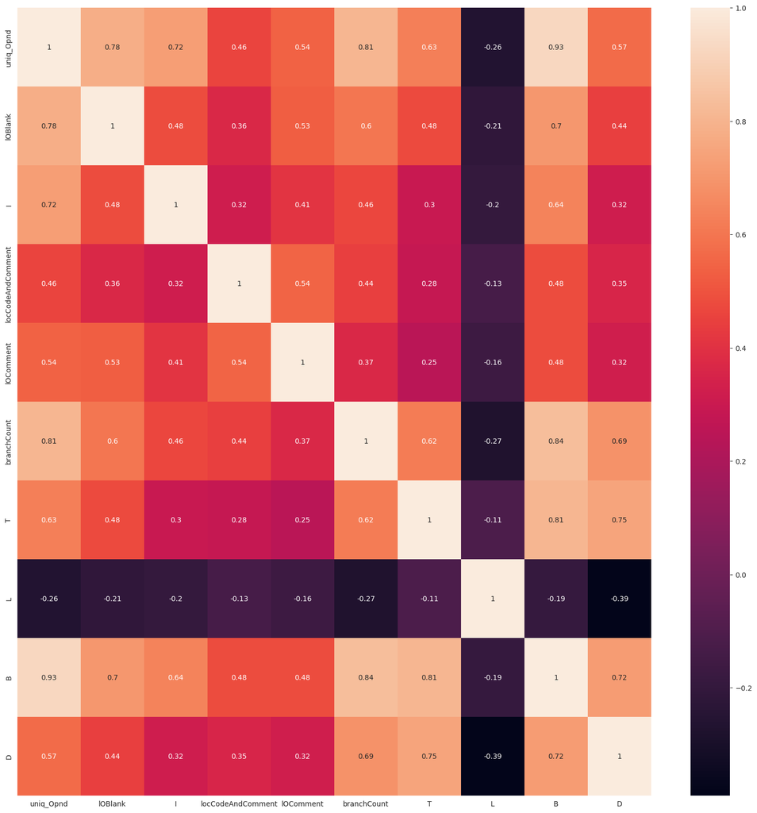

```python
import matplotlib.pyplot as plt
import seaborn as sns

plt.figure(figsize=(20, 20))
sns.heatmap(X_train[['uniq_Opnd', 'lOBlank', 'I', 'locCodeAndComment', 'lOComment', 'branchCount', 'T', 'L', 'B', 'D']].corr(), annot=True)
plt.show()
```

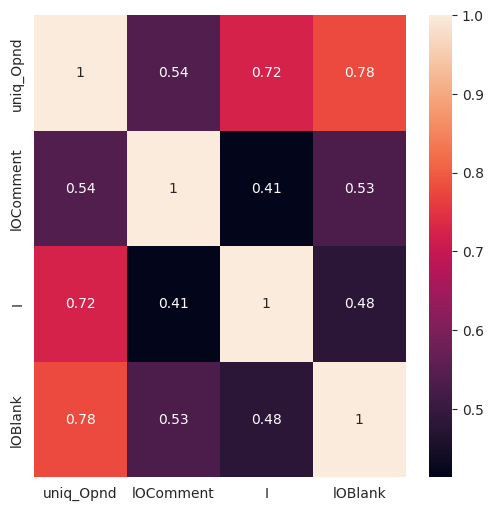

```python
plt.figure(figsize=(6, 6))
sns.heatmap(X_train[['uniq_Opnd', 'lOComment', 'I', 'lOBlank']].corr(), annot=True)
plt.show()
```

### Models

```python
from sklearn.linear_model import LogisticRegression
from sklearn.ensemble import RandomForestClassifier
import dalex as dx
from xgboost import XGBClassifier


def dx_predict_proba(model, df):
    return model.predict_proba(df)[:, 1]


RANDOM_STATE = 42

models = {
    'RandomForest': RandomForestClassifier(random_state=RANDOM_STATE, n_jobs=-1),
    'XGBoost': XGBClassifier(random_state=RANDOM_STATE, n_jobs=-1),
    'LogisticRegression': LogisticRegression(random_state=RANDOM_STATE, n_jobs=-1),
    'SmallRandomForest': RandomForestClassifier(n_estimators=10, max_depth=10, random_state=RANDOM_STATE, n_jobs=-1),
}

explainers = {}

for model_name, model in models.items():
    print(f'Fitting {model_name}...')
    model.fit(X_train, y_train)
    print(f'{model_name} predictions')
    explainer = dx.Explainer(model, X_test, y_test, predict_function=dx_predict_proba, label=model_name)
    explainers[model_name] = explainer
```

### Performance

```python
display(pd.concat([explainer.model_performance().result for explainer in explainers.values()], axis=0))
```

|  | recall | precision | f1 | accuracy | auc |
| --- | --- | --- | --- | --- | --- |
| RandomForest | 0.200000 | 0.750000 | 0.315789 | 0.928962 | 0.816071 |
| XGBoost | 0.233333 | 0.636364 | 0.341463 | 0.926230 | 0.805208 |
| LogisticRegression | 0.133333 | 0.571429 | 0.216216 | 0.920765 | 0.835764 |
| SmallRandomForest | 0.233333 | 0.583333 | 0.333333 | 0.923497 | 0.761558 |

### PVI for RandomForest

```python
pvi = explainers['RandomForest'].model_parts(random_state=RANDOM_STATE)
```

```python
display(pvi.result)
```

|  | variable | dropout_loss | label |
| --- | --- | --- | --- |
| 0 | E | 0.173418 | RandomForest |
| 1 | iv(G) | 0.180402 | RandomForest |
| 2 | total_Op | 0.181146 | RandomForest |
| 3 | N | 0.183631 | RandomForest |
| 4 | lOCode | 0.183661 | RandomForest |
| 5 | _full_model_ | 0.183929 | RandomForest |
| 6 | uniq_Op | 0.186280 | RandomForest |
| 7 | V | 0.188338 | RandomForest |
| 8 | ev(g) | 0.188517 | RandomForest |
| 9 | total_Opnd | 0.189231 | RandomForest |
| 10 | v(g) | 0.189940 | RandomForest |
| 11 | loc | 0.190377 | RandomForest |
| 12 | D | 0.193442 | RandomForest |
| 13 | B | 0.198309 | RandomForest |
| 14 | L | 0.198785 | RandomForest |
| 15 | T | 0.201468 | RandomForest |
| 16 | branchCount | 0.208239 | RandomForest |
| 17 | lOComment | 0.212004 | RandomForest |
| 18 | locCodeAndComment | 0.229757 | RandomForest |
| 19 | I | 0.248472 | RandomForest |
| 20 | lOBlank | 0.273661 | RandomForest |
| 21 | uniq_Opnd | 0.277589 | RandomForest |
| 22 | _baseline_ | 0.475565 | RandomForest |

```python
pvi.plot(show=False).update_layout(autosize=False, width=600, height=450)
```

[interactive chart not shown]

### PVI all models

```python
for explainer in explainers.values():
    pvi = explainer.model_parts(random_state=RANDOM_STATE)
    pvi.plot(show=False).update_layout(autosize=False, width=600, height=450).show()
```

[interactive chart not shown]

### Gini for RandomForest

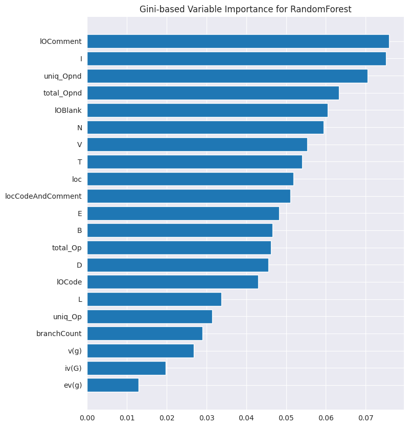

```python
model = models['RandomForest']

df_variables_importance = pd.DataFrame({'variable': X_test.columns, 'importance': model.feature_importances_}).sort_values(by='importance', ascending=True)

# figsize
plt.figure(figsize=(8, 10))
# x axis names horizontally
plt.yticks(rotation=0)
plt.barh(df_variables_importance['variable'].values, df_variables_importance['importance'].values)
plt.title("Gini-based Variable Importance for RandomForest")
plt.show()
```

### SHAP

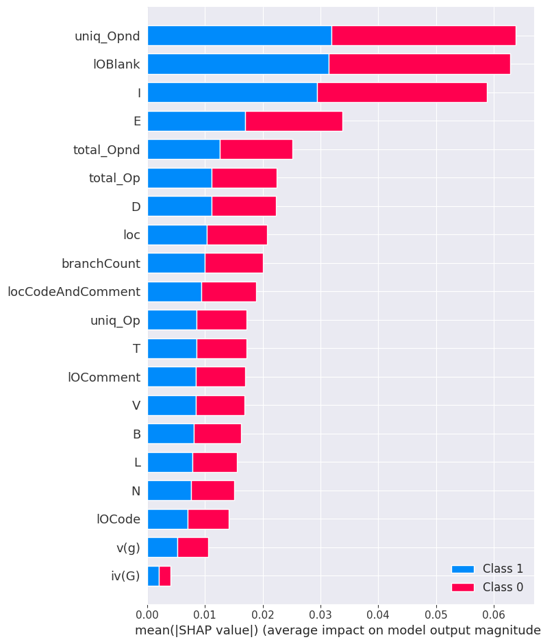

```python
import shap

explainer = shap.TreeExplainer(model, X_train, model_output='probability')
shap_values = explainer.shap_values(X_test)
shap.summary_plot(shap_values, X_test)
```